# Votos ONU

Mine Çetinkaya-Rundel

2020-09-16

## Introdução

Como vários países votam na Assembleia Geral das Nações Unidas, como seus padrões de votação evoluíram ao longo do tempo, e quão semelhante ou diferente eles veem certos problemas? Responder a essas perguntas (em alto nível) é o foco desta análise.

### Pacotes

Usaremos os pacotes **tidyverse**, **lubridate** e **scales** para o preparação e visualização de dados, e o pacote **DT** para exibição interativa de saída tabular.

```r
library(tidyverse)
library(lubridate)
library(scales)
library(DT)
```

### Dados

Os dados que estamos usando vêm originalmente do pacote **unvotes**, mas tem sido modificado (juntando os vários dados fornecidos no pacote) para ajudá-lo a começar a análise.

```r
library(unvotes)
library(tidyverse)
library(here)
unvotes <- un_votes %>%
  mutate(country =
           case_when(
             country == "United Kingdom of Great Britain and Northern Ireland" ~ "UK & NI",
             country == "United States of America"                             ~ "US",
             TRUE                                                              ~ country
           )) %>%
  inner_join(un_roll_calls, by = "rcid") %>%
  inner_join(un_roll_call_issues, by = "rcid")
```

## Padrões de votação da ONU

Podemos facilmente alterar quais países estão sendo plotados, alterando quais países para os quais o código acima do `filter`. Observe que o nome do país deve ser escrito e capitalizado exatamente da mesma maneira que aparece nos dados. Vejo o Apêndice para uma lista dos países nos dados.

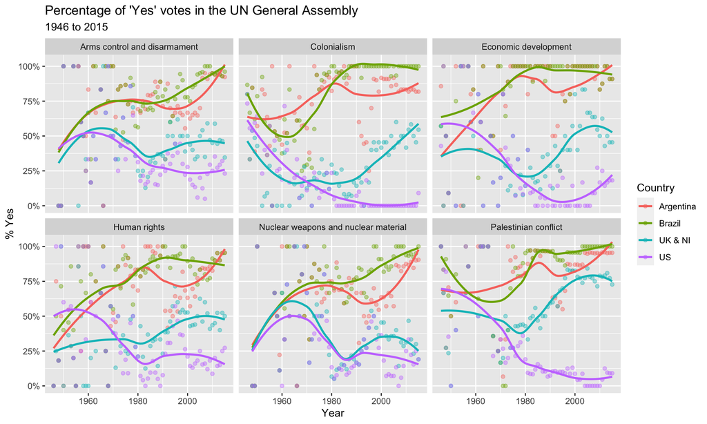

```r
unvotes %>%
  filter(country %in% c("UK & NI", "US", "Brazil", "Argentina")) %>%
  mutate(year = year(date)) %>%
  group_by(country, year, issue) %>%
  summarize(percent_yes = mean(vote == "yes")) %>%
  ggplot(mapping = aes(x = year, y = percent_yes, color = country)) +
  geom_point(alpha = 0.4) +
  geom_smooth(method = "loess", se = FALSE) +
  facet_wrap(~issue) +
  scale_y_continuous(labels = percent) +
  labs(
    title = "Percentage of 'Yes' votes in the UN General Assembly",
    subtitle = "1946 to 2015",
    y = "% Yes",
    x = "Year",
    color = "Country"
  )
```

## Referências

1. David Robinson (2017). unvotes: United Nations General Assembly Voting Data. R package version 0.2.0.
2. Erik Voeten “Data and Analyses of Voting in the UN General Assembly” Routledge Handbook of International Organization, edited by Bob Reinalda (published May 27, 2013).
3. Much of the analysis has been modeled on the examples presented in the [unvotes package vignette](https://cran.r-project.org/web/packages/unvotes/vignettes/unvotes.html).

## Apêndice

Abaixo está uma lista de países no conjunto de dados:

|  | country |
| --- | --- |
| 1 | Afghanistan |
| 2 | Albania |
| 3 | Algeria |
| 4 | Andorra |
| 5 | Angola |
| 6 | Antigua and Barbuda |
| 7 | Argentina |
| 8 | Armenia |
| 9 | Australia |
| 10 | Austria |

[output cut: 189 more lines]